# Linear Model with Prediction

Ezra Licciardi

2023-10-25

```r
url <- "https://onlinestatbook.com/case_studies_rvls/physical_strength/data.txt"
mydata <- read.csv(file=url,sep="",header=TRUE)
```

# 1 Introduction

We are looking at data procured from RVLS regarding “Physical Strength and Job Performance”. We are exploring this data to see if any statistically significant correlations exist in the data or if the data is meaningfully related.

$H_0$ There are no statistically meaningful relation in the data.

$H_A$ There are statistically meaningful relation in the data.

# 2 Methods

```r
glimpse(mydata)
```

```
## Rows: 147
## Columns: 4
## $ GRIP    <dbl> 105.5, 106.5, 94.0, 90.5, 104.0, 171.0, 107.5, 124.5, 87.0, 10…
## $ ARM     <dbl> 80.5, 93.0, 81.0, 33.5, 47.5, 125.5, 81.5, 83.5, 65.0, 77.5, 5…
## $ RATINGS <dbl> 31.800, 39.800, 46.800, 52.200, 31.200, 46.600, 29.800, 39.000…
## $ SIMS    <dbl> 1.18, 0.94, 0.84, -2.45, 1.00, 4.38, -0.38, -0.01, -0.99, -0.0…
```

```r
model1 <- lm(SIMS~ARM,data=mydata)
model2 <- lm(SIMS~GRIP,data=mydata)
model3 <- lm(SIMS~ARM+GRIP,data=mydata)

sims <- mean(mydata$SIMS)
target1 <- data.frame(ARM=88,GRIP=94)
```

Looking at the data provided they are all of data type: double meaning that they are continuous numerical data. This means that all problems in this write up will be of the numerical~numerical type.

With the CandP helper file we will use scatter plots, correlation coefficients, and linear regression to explore the data.

# 3 Results

## 3.1 Graphical Results

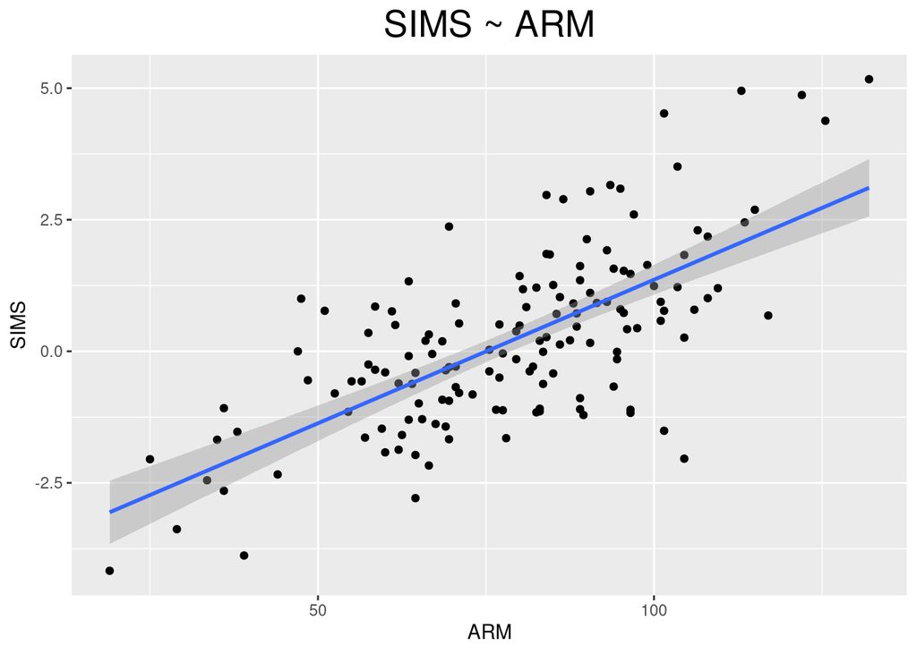

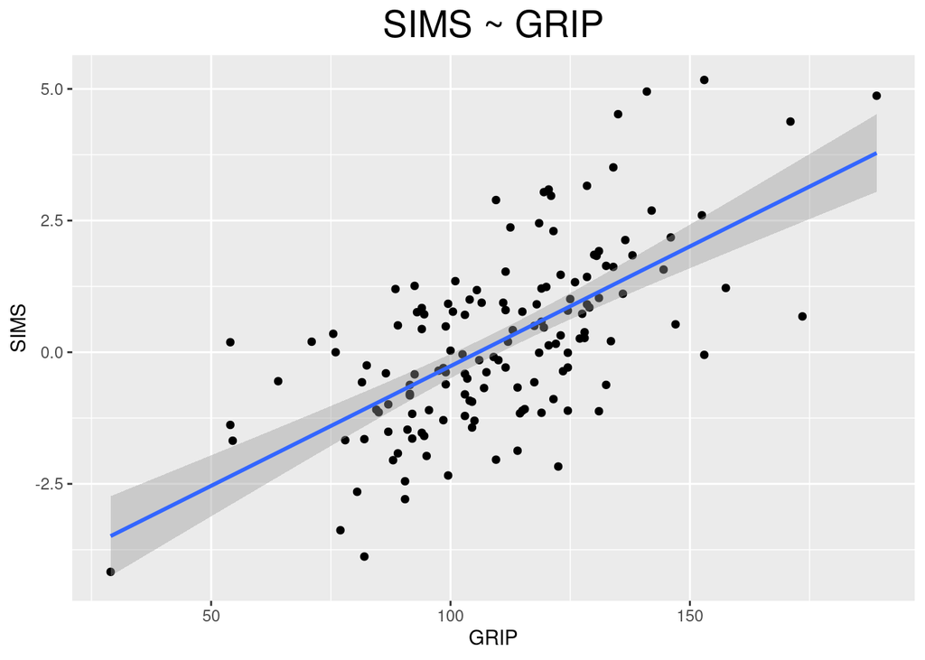

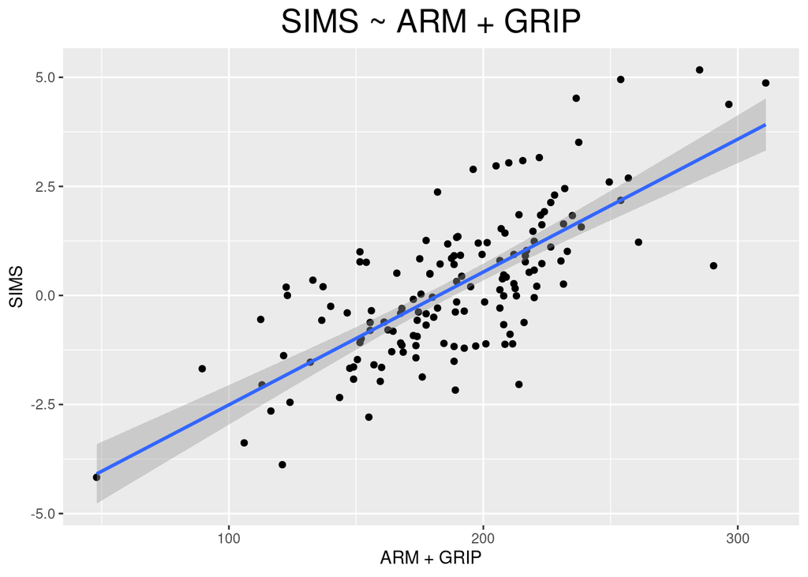

We can see here that all of the data is positively correlated at a glance but we do not know which of these is the best fit for our desired prediction.

## 3.2 Numerical Results

```r
cor(SIMS~ARM,data=mydata)
```

```
## [1] 0.6860073
```

```r
cor(SIMS~GRIP,data=mydata)
```

```
## [1] 0.6398458
```

```r
cor(SIMS~ARM+GRIP,data=mydata)
```

```
## [1] 0.7326545
```

Given these correlation coefficients we can show that the model 3 has the psrongest correlation, 1 being a one to one relationship 0.7 is the closest we have here.

## 3.3 Inferential Results

```
## Model 1
```

```
##
## Call:
## lm(formula = SIMS ~ ARM, data = mydata)
##
## Residuals:
##     Min      1Q  Median      3Q     Max
## -3.6467 -0.7502 -0.0285  0.6875  3.0770
##
## Coefficients:
##              Estimate Std. Error t value Pr(>|t|)
## (Intercept) -4.095160   0.391745  -10.45   <2e-16 ***
## ARM          0.054563   0.004806   11.35   <2e-16 ***
## ---
## Signif. codes:  0 '***' 0.001 '**' 0.01 '*' 0.05 '.' 0.1 ' ' 1
##
## Residual standard error: 1.226 on 145 degrees of freedom
## Multiple R-squared:  0.4706, Adjusted R-squared:  0.467
## F-statistic: 128.9 on 1 and 145 DF,  p-value: < 2.2e-16
```

```
##         fit       lwr      upr
## 1 0.7063836 -1.726209 3.138977
```

```
## 4.8 = Difference
```

```
## Model 2
```

```
##
## Call:
## lm(formula = SIMS ~ GRIP, data = mydata)
##
## Residuals:
##     Min      1Q  Median      3Q     Max
## -2.9295 -0.8708 -0.1219  0.8039  3.3494
##
## Coefficients:
##              Estimate Std. Error t value Pr(>|t|)
## (Intercept) -4.809675   0.511141   -9.41   <2e-16 ***
## GRIP         0.045463   0.004535   10.03   <2e-16 ***
## ---
## Signif. codes:  0 '***' 0.001 '**' 0.01 '*' 0.05 '.' 0.1 ' ' 1
##
## Residual standard error: 1.295 on 145 degrees of freedom
## Multiple R-squared:  0.4094, Adjusted R-squared:  0.4053
## F-statistic: 100.5 on 1 and 145 DF,  p-value: < 2.2e-16
```

```
##          fit       lwr      upr
## 1 -0.5361543 -3.107961 2.035652
```

[output not shown]

```
## Model 3
```

```
##
## Call:
## lm(formula = SIMS ~ ARM + GRIP, data = mydata)
##
## Residuals:
##     Min      1Q  Median      3Q     Max
## -3.1846 -0.7380 -0.0641  0.7394  2.8634
##
## Coefficients:
##              Estimate Std. Error t value Pr(>|t|)
## (Intercept) -5.433871   0.461815 -11.766  < 2e-16 ***
## ARM          0.037311   0.005774   6.462 1.50e-09 ***
## GRIP         0.024470   0.005158   4.744 4.99e-06 ***
## ---
## Signif. codes:  0 '***' 0.001 '**' 0.01 '*' 0.05 '.' 0.1 ' ' 1
##
## Residual standard error: 1.144 on 144 degrees of freedom
## Multiple R-squared:  0.5422, Adjusted R-squared:  0.5358
## F-statistic: 85.26 on 2 and 144 DF,  p-value: < 2.2e-16
```

```
##         fit       lwr      upr
## 1 0.1496476 -2.132373 2.431668
```

```
## 4.6 = Difference
```

Here with our linear models of the data constructed from models 1 through 3 we have several metrics to see which model best fits our data.

We can compare Residual Standard Error which model 3 has the lowest at $\approx 1.1$, Adjusted R-Squared which is closest to one at $\approx0.5$

Finally we constricted a target at an arbitrary point an interval prediction. We see that model three has the smallest difference in the lower and upper bounds of the prediction at $\approx4.6$.

```
## Model 1 & 2
```

```
## Analysis of Variance Table
##
## Model 1: SIMS ~ ARM
## Model 2: SIMS ~ GRIP
##   Res.Df    RSS Df Sum of Sq F Pr(>F)
## 1    145 217.88
## 2    145 243.07  0   -25.189
```

```
##
##
##
##  Model 2 & 3
```

```
## Analysis of Variance Table
##
## Model 1: SIMS ~ GRIP
## Model 2: SIMS ~ ARM + GRIP
##   Res.Df    RSS Df Sum of Sq      F    Pr(>F)
## 1    145 243.07
## 2    144 188.43  1    54.639 41.755 1.495e-09 ***
## ---
## Signif. codes:  0 '***' 0.001 '**' 0.01 '*' 0.05 '.' 0.1 ' ' 1
```

```
##
##
##
##  Model 1 & 3
```

```
## Analysis of Variance Table
##
## Model 1: SIMS ~ ARM
## Model 2: SIMS ~ ARM + GRIP
##   Res.Df    RSS Df Sum of Sq      F    Pr(>F)
## 1    145 217.88
## 2    144 188.43  1     29.45 22.506 4.994e-06 ***
## ---
## Signif. codes:  0 '***' 0.001 '**' 0.01 '*' 0.05 '.' 0.1 ' ' 1
```

# 4 Conclusion and Discussion

In conclusion we can reject the null hypothesis that there is no relations between the data. We have seen from the regression lines on the scatter plot that the data is overall positively correlation. The correlation coefficients are also closer to one than zero indicating that there is a relationship. In picking the best model we compared adjusted R squared values, residual standard errors as well as using the predict function to compare the width of the confidence interval. Model three was the best fit in all catagories and was once again compared with a one way anova where it has the lowest P-Value of the options.

We can say that physical strength is a good indicator of job preformance in this study and that combining arm and grip strength is the best way to predict this from the data provided.